# Лабораторная работа №5

Управление системными службами

Чекмарев Александр Дмитриевич | Группа НПИбд-03-24

Российский университет дружбы народов, Москва, Россия

20 Декабря 2025

# Информация

## Докладчик

- Чекмарев Александр Дмитриевич
- Группа НПИбд-03-24
- Российский университет дружбы народов
- https://github.com/nenokixd?tab=repositories

# Вводная часть

## Объект и предмет исследования

- Управления системными службами операционной системы посредством systemd

## Цель работы

- Получить навыки управления системными службами операционной системы посредством systemd.

# Ход лаборатороной работы

## Управление сервисами

- Зайдем в режим root. Проверяем статус службы Very Secure FTP: **systemctl status vsftpd**.
- Вывод команды показывает, что сервис в настоящее время отключён, так как служба Very Secure FTP не установлена

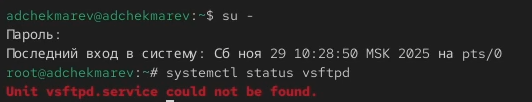

## Управление сервисами

- Устанавливаем службу Very Secure FTP: **dnf -y install vsftpd**

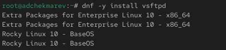

## Управление сервисами

- Запускаем службу Very Secure FTP. Проверяем статус службы Very Secure FTP.
- Вывод команды показывает, что служба в настоящее время работает, но не будет активирована при перезапуске операционной системы

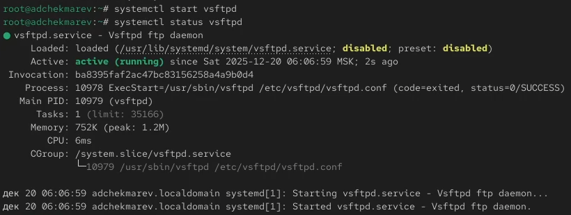

## Управление сервисами

- Добавляем службу Very Secure FTP в автозапуск при загрузке операционной системы, используя команду: **systemctl enable vsftpd**
- Проверяем статус службы Very Secure FTP

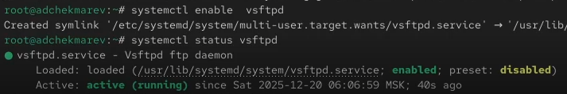

## Управление сервисами

- Удаляем службу из автозапуска, используя команду **systemctl disable vsftpd**, и снова проверяем её статус

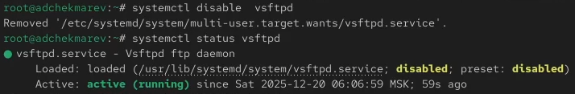

## Управление сервисами

- Выводим на экран символические ссылки, ответственные за запуск различных сервисов: **ls /etc/systemd/system/multi-user.target.wants**.
- После ввода этой команды отображается, что ссылки на vsftpd.service не существует

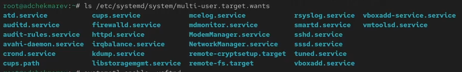

## Управление сервисами

- Снова добавляем службу Very Secure FTP в автозапуск и опять выводим на экран символические ссылки, ответственные за запуск различных сервисов.
- На этот раз вывод команды показывает, что создана символическая ссылка для файла /usr/lib/systemd/system/vsftpd.service в каталоге /etc/systemd/system/multi-user.target.wants

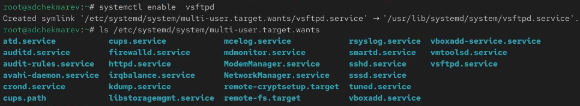

## Управление сервисами

- Проверяем статус службы Very Secure FTP. Мы видим, что для файла юнита состояние изменено с disabled на enabled

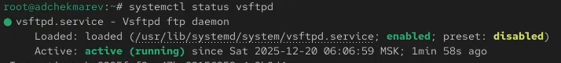

## Управление сервисами

- Выводим на экран список зависимостей юнита: **systemctl list-dependencies vsftpd**

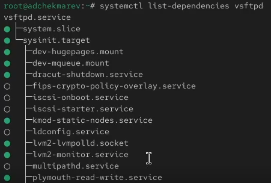

## Управление сервисами

- Выводим на экран список юнитов, которые зависят от данного юнита: **systemctl list-dependencies vsftpd –reverse**

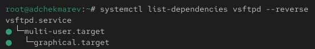

## Конфликты юнитов

- Устанавливаем iptables: **dnf -y install iptables***

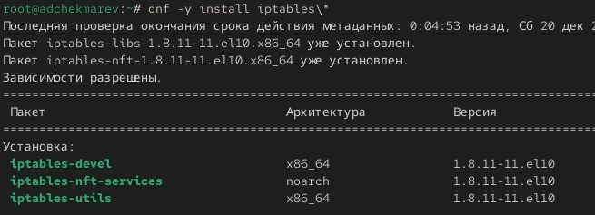

## Конфликты юнитов

- Далее проверяем статус firewalld и iptables

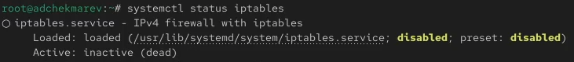

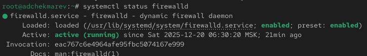

## Конфликты юнитов

- Далее пробуем запустить firewalld и iptables. При запуске одной службы мы видим, что вторая дезактивируется или не запускается

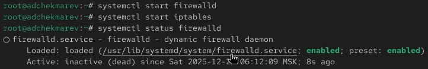

## Конфликты юнитов

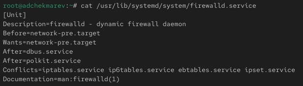

## Конфликты юнитов

- Вводим **cat /usr/lib/systemd/system/iptables.service**.
- Описание настроек конфликтов: в данном юните параметр Conflicts отсутствует, что означает, что конфликтов с другими службами не указано.
- Хотя в юните iptables не указаны конфликты, мы знаем из предыдущей конфигурации firewalld, что firewalld указывает iptables как конфликтующую службу.
- Это означает, что если firewalld работает, то iptables не должен быть запущен одновременно, так как это может привести к конфликтам в управлении firewalld.

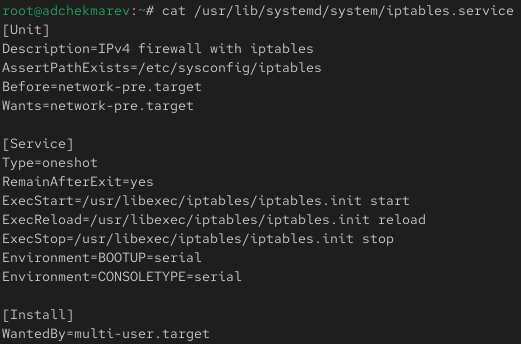

## Конфликты юнитов

- Выгружаем службу iptables (на всякий случай, чтобы убедиться, что данная служба не загружена в систему): **systemctl stop iptables**.
- После загружаем службу firewalld

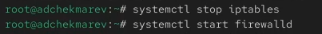

## Конфликты юнитов

- Далее блокируем запуск iptables, введя: **systemctl mask iptables**.
- При этом будет создана символическая ссылка на /dev/null для /etc/systemd/system/iptables.service.
- Поскольку юнитфайлы в /etc/systemd имеют приоритет над файлами в /usr/lib/systemd, то это сделает невозможным случайный запуск сервиса iptables

## Конфликты юнитов

- Пробуем запустить iptables м добавить iptables в автозапуск.
- При попытке запустить iptables появляется сообщение об ошибке, указывающее, что служба замаскирована и по этой причине не может быть запущена.
- Сервис будет неактивен, а статус загрузки отобразится как замаскированный.

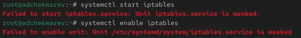

## Изолируемые цели

- Переходим в каталог systemd и находим список всех целей, которые можно изолировать:

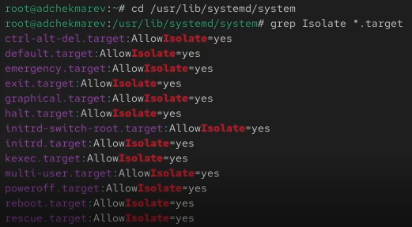

## Изолируемые цели

- Далее переключаем операционную систему в режим восстановления: **systemctl isolate rescue.target**
- Переходим в режим root и перезапускаем операционную систему: **systemctl isolate reboot.target**
- У меня не выводит консоль, я не знаю что делать, поэтому эти два пункта пропущены.

## Цель по умолчанию

- Получаем права администратора. Далее выводим на экран цель, установленную по умолчанию: **systemctl get-default**.
- Сейчас графический режим

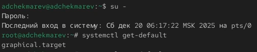

## Цель по умолчанию

- Для установки цели по умолчанию используется команда **systemctl set-default**.
- Запускаем по умолчанию текстовый режим введя команду **systemctl set-default multi-user.target** и перезагружаем систему командой **reboot**

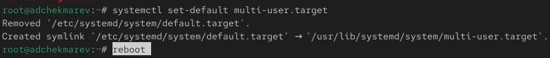

## Цель по умолчанию

- Система загрузилась в текстовом режиме.
- Получаем полномочия пользователя root и запускаем по умолчанию графический режим введя команду **systemctl set-default graphical.target**.
- Снова перезагружаем систему командой **reboot**

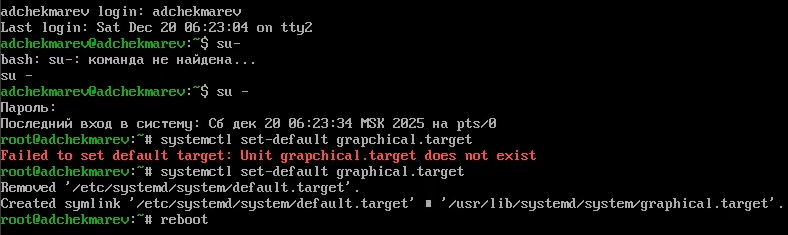

- Система загрузилась в графическом режиме.

## Вывод:

В ходе работы приобретены умения по работе с управлением системными службами операционной системы посредством systemd